# STAT656: Introductory Flight Example

Getting oriented with R, R Markdown, and tidying

# Reading in the data

We want to load in the data (after inspecting it in some manner e.g. the unix command ‘head -3 934548400_T_ONTIME_REPORTING.csv’). We can alternatively inspect it through R itself:

```r
readLines('934548400_T_ONTIME_REPORTING.csv', n = 3)
```

```
## [1] "\"DAY_OF_MONTH\",\"ORIGIN_AIRPORT_ID\",\"ORIGIN_AIRPORT_SEQ_ID\",\"ORIGIN_CITY_MARKET_ID\",\"ORIGIN\",\"DEP_DELAY\",\"DEP_DELAY_NEW\",\"DEP_DEL15\","
## [2] "1,11618,1161802,31703,\"EWR\",-5.00,0.00,0.00,"
## [3] "1,12889,1288903,32211,\"LAS\",-8.00,0.00,0.00,"
```

We find that there is a mixture of numeric and string data. ALso, there is a trailing empty column due to the comma ending each line. The [read.csv](https://www.youtube.com/watch?v=qK1ElUMkhq0&list=PLOU2XLYxmsIK9qQfztXeybpHvru-TrqAP&index=9&t=3s) function automatically interprets strings as [factors](https://cran.r-project.org/doc/manuals/R-intro.html#Factors). We are going to sub-select from the levels of this qualitative explanatory variable, so we don’t want it to create a factor on import (after reading/experimenting with factors, why would this matter?)

```r
flightData = read.csv('934548400_T_ONTIME_REPORTING.csv',header=TRUE,stringsAsFactors = FALSE)
```

Now, we would want to see if what we got is what we expect. For instance, the dimensions are 570118, 9.

# Some data structure comments

In computer science, a data structure is a storage format for information. We have seen one so far:

## Strings/Characters

```r
stringExample = 'any quoted is a string'
print(stringExample)
```

```
## [1] "any quoted is a string"
```

```r
paste(stringExample,"double quotes also work",sep='; ')
```

```
## [1] "any quoted is a string; double quotes also work"
```

```r
is.character(stringExample)
```

```
## [1] TRUE
```

```r
typeof(stringExample)
```

```
## [1] "character"
```

## Floats and integers

```r
floatExample = 1
print(floatExample)
```

```
## [1] 1
```

```r
is.double(floatExample)
```

```
## [1] TRUE
```

```r
typeof(floatExample)
```

```
## [1] "double"
```

```r
object.size(floatExample)
```

```
## 56 bytes
```

## data.frame

By default, the output of read.csv is a [data.frame](https://www.youtube.com/watch?v=qK1ElUMkhq0&list=PLOU2XLYxmsIK9qQfztXeybpHvru-TrqAP&index=9&t=0s). This can be checked in a several ways, namely

```r
is.data.frame(flightData)
```

```
## [1] TRUE
```

We are going to be using a very nice implementation of the “Split-Apply-Combine” idea known as the [tidyverse](https://r4ds.had.co.nz/index.html). The first step is to convert the object from a data.frame to a tibble.

# Installing/loading packages

R works by having some base functions that are always loaded (e.g. typeof). To keep things uncluttered, all the extra functionality are kept in packages that must be installed and the loaded into memory. Let’s do just that with the tidyverse package:

```r
if(!require(tidyverse)){install.packages('tidyverse');require(tidyverse)}
```

Note that here I’ve used [conditionals](https://www.youtube.com/watch?v=eVEx_pBEkRI&list=PLOU2XLYxmsIK9qQfztXeybpHvru-TrqAP&index=11&t=0s)

# The tibble data structure

If we have a data.frame, we can usually convert it to a [tibble](https://r4ds.had.co.nz/tibbles.html) by doing:

```r
flightDataTB = as_tibble(flightData)
flightDataTB
```

```
## # A tibble: 570,118 x 9
##    DAY_OF_MONTH ORIGIN_AIRPORT_… ORIGIN_AIRPORT_… ORIGIN_CITY_MAR… ORIGIN
##           <int>            <int>            <int>            <int> <chr>
##  1            1            11618          1161802            31703 EWR
##  2            1            12889          1288903            32211 LAS
##  3            1            14908          1490803            32575 SNA
##  4            1            14635          1463502            31714 RSW
##  5            1            13930          1393006            30977 ORD
##  6            1            13930          1393006            30977 ORD
##  7            1            12266          1226603            31453 IAH
##  8            1            11292          1129202            30325 DEN
##  9            1            14893          1489302            33192 SMF
## 10            1            14524          1452401            34524 RIC
## # … with 570,108 more rows, and 4 more variables: DEP_DELAY <dbl>,
## #   DEP_DELAY_NEW <dbl>, DEP_DEL15 <dbl>, X <lgl>
```

Note that a nice feature of tibble is that it only prints the header, not the whole object (if we had tried this with flightData, it would have printed out 570118 rows. Try it, if you dare!)

Note that we can directly import into the tibble data structure using [read_csv](https://r4ds.had.co.nz/data-import.html)

```r
flightDataTB = read_csv('934548400_T_ONTIME_REPORTING.csv')
names(flightDataTB)
```

```
## [1] "DAY_OF_MONTH"          "ORIGIN_AIRPORT_ID"     "ORIGIN_AIRPORT_SEQ_ID"
## [4] "ORIGIN_CITY_MARKET_ID" "ORIGIN"                "DEP_DELAY"
## [7] "DEP_DELAY_NEW"         "DEP_DEL15"             "X9"
```

```r
flightDataTB
```

```
## # A tibble: 570,118 x 9
##    DAY_OF_MONTH ORIGIN_AIRPORT_… ORIGIN_AIRPORT_… ORIGIN_CITY_MAR… ORIGIN
##           <dbl>            <dbl>            <dbl>            <dbl> <chr>
##  1            1            11618          1161802            31703 EWR
##  2            1            12889          1288903            32211 LAS
##  3            1            14908          1490803            32575 SNA
##  4            1            14635          1463502            31714 RSW
##  5            1            13930          1393006            30977 ORD
##  6            1            13930          1393006            30977 ORD
##  7            1            12266          1226603            31453 IAH
##  8            1            11292          1129202            30325 DEN
##  9            1            14893          1489302            33192 SMF
## 10            1            14524          1452401            34524 RIC
## # … with 570,108 more rows, and 4 more variables: DEP_DELAY <dbl>,
## #   DEP_DELAY_NEW <dbl>, DEP_DEL15 <dbl>, X9 <lgl>
```

# Back to the question

In there any difference in delay length in January 2018 between IAH or DFW?

Continuing to convert this to a statistical question, we can look into testing if the population mean delay time at IAH equals the population mean delay time at DFW.

Let’s use split/apply/combine to get the relevant information. A good metaphor for thinking about this is in terms of `grammar’; there are nouns (the objects) and verbs (the functions). We will keep exploring this idea, but here is brief glimpse

```r
flightDataTB_originDelay       = select(flightDataTB,ORIGIN,DEP_DELAY_NEW,DEP_DELAY)
flightDataTB_originDelayIAHDFW = filter(flightDataTB_originDelay, ORIGIN == 'IAH' | ORIGIN == 'DFW')
dim(flightDataTB_originDelayIAHDFW)
```

```
## [1] 36407     3
```

Before we get too far here, let’s make an adjustment to this code. Notice how we are getting complicated object names and writing very similar things over and over? It is very easy for typos and bugs to appear in your code this way. [Pipes](https://r4ds.had.co.nz/pipes.html) to the rescue!

```r
flightDataTB  %>%
  select(ORIGIN,DEP_DELAY_NEW, DEP_DELAY) %>%
  filter(ORIGIN == 'IAH' | ORIGIN == 'DFW') %>%
  dim(.)
```

```
## [1] 36407     3
```

Much cleaner, easier to read, and debug. Now, we are free to investigate the question statistically.

```r
(Ybar = flightDataTB  %>%
  select(ORIGIN,DAY_OF_MONTH, DEP_DELAY_NEW, DEP_DELAY) %>%
  filter(ORIGIN == 'IAH' | ORIGIN == 'DFW') %>%
  group_by(ORIGIN) %>%
  summarise(Ybar = mean(DEP_DELAY_NEW, na.rm = TRUE)))
```

```
## # A tibble: 2 x 2
##   ORIGIN  Ybar
##   <chr>  <dbl>
## 1 DFW     9.88
## 2 IAH    10.9
```

So, we get Ybar_IAH = 10.8856075 and Ybar_DFW = 9.8821943. It’s not surprising, of course, to find that the sample means are not equal. Let’s form a confidence interval via a pooled two-sample t-test:

```r
flightDataTB_ttest = flightDataTB  %>%
  select(ORIGIN, DAY_OF_MONTH, DEP_DELAY_NEW, DEP_DELAY) %>%
  filter(ORIGIN == 'IAH' | ORIGIN == 'DFW')

confint(lm(DEP_DELAY_NEW ~ ORIGIN, data = flightDataTB_ttest))
```

```
##                2.5 %    97.5 %
## (Intercept) 9.382367 10.382021
## ORIGINIAH   0.191981  1.814845
```

Of course, no statistical method should be applied without looking into the assumptions! These are:

- The observations are drawn from a normal distribution
- The standard deviations are the same between the two groups
- The observations are independent

So, before we attempt to interpret these results, we need to make some plots. We will be using a very nice accessory package to dplyr: [ggplot2](https://r4ds.had.co.nz/data-visualisation.html). The package ggplot2 works again via a grammar, which is loosly like ‘what am I plotting?’ + ‘what does the plot look like’? I suggest you look at the suggested link to get familiar with ggplot2.

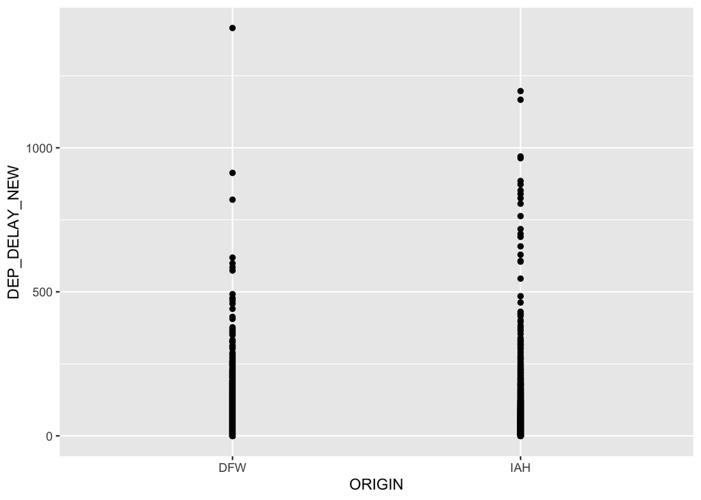

```r
ggplot(data = flightDataTB_ttest) +
  geom_point(mapping = aes(x = ORIGIN, y = DEP_DELAY_NEW))
```

This is somewhat helpful. We can tell right away that the observations are positively skewed and hence not from a normal distribution. Additionally, we can see that there was one flight that was particularly delayed from DFW. Let’s make a visualization based on a density estimator such as a histogram (see Figure 1.3 in APM for an example)

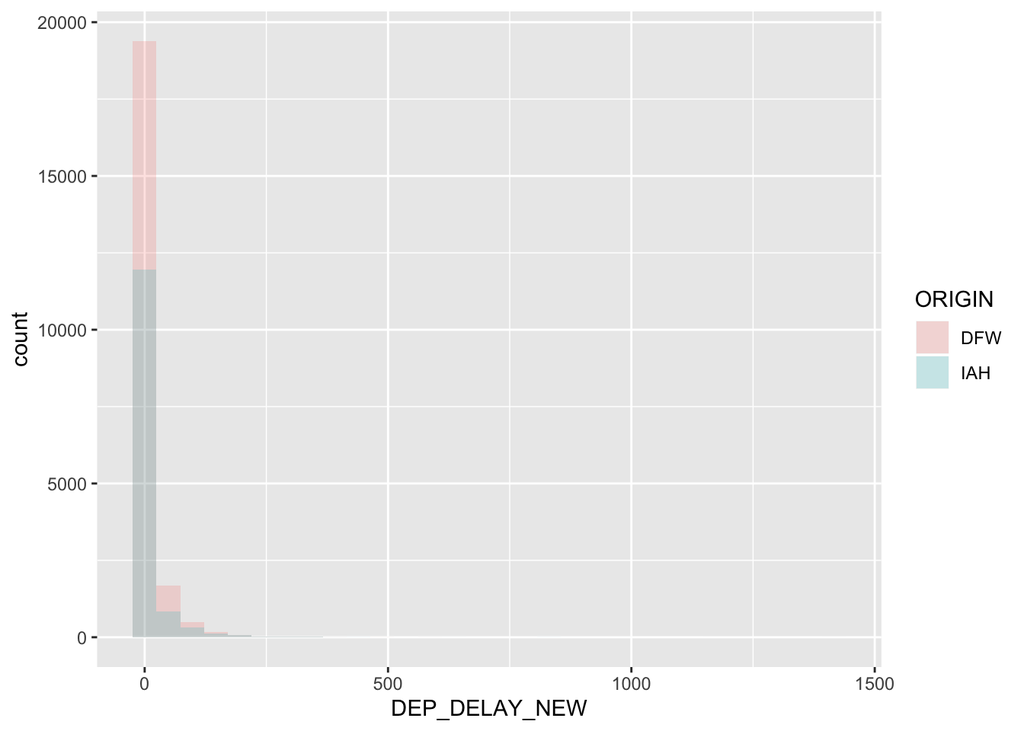

```r
ggplot(data = flightDataTB_ttest, mapping = aes(x = DEP_DELAY_NEW, fill = ORIGIN)) +
  geom_histogram(alpha=0.2, position="identity")
```

This is a count-based histogram. It is usually better to look at the density (this just divides each count by the number of observation). Also, let’s pick a bigger binwidth

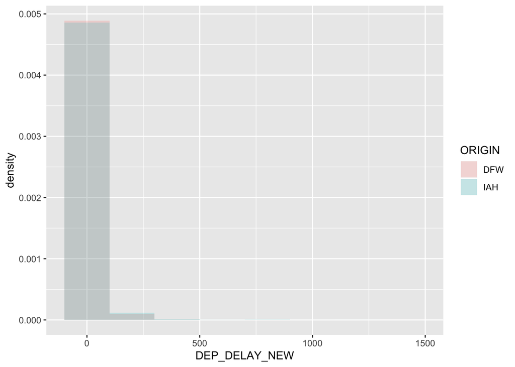

```r
ggplot(data = flightDataTB_ttest, mapping = aes(x = DEP_DELAY_NEW, y = ..density.., fill = ORIGIN)) +
  geom_histogram(alpha=0.2, position="identity",binwidth = 200)
```

Later in the class, we can re-address this using the bootstrap. What about the independence assumption? Let’s look at a plot over time for the month

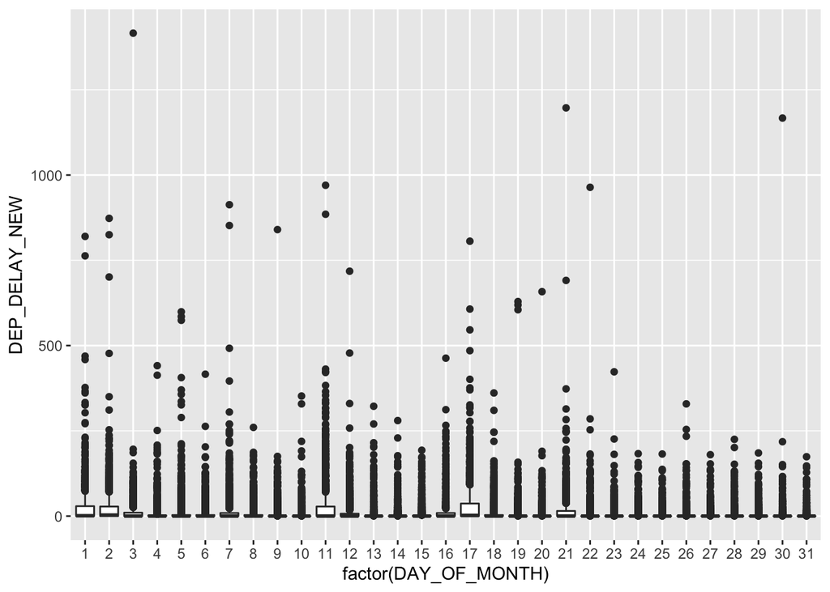

```r
ggplot(data = flightDataTB_ttest, mapping = aes(x = factor(DAY_OF_MONTH), y = DEP_DELAY_NEW)) +
  geom_boxplot()
```

Not much to see here, maybe we can plot the median flight delay by day of month

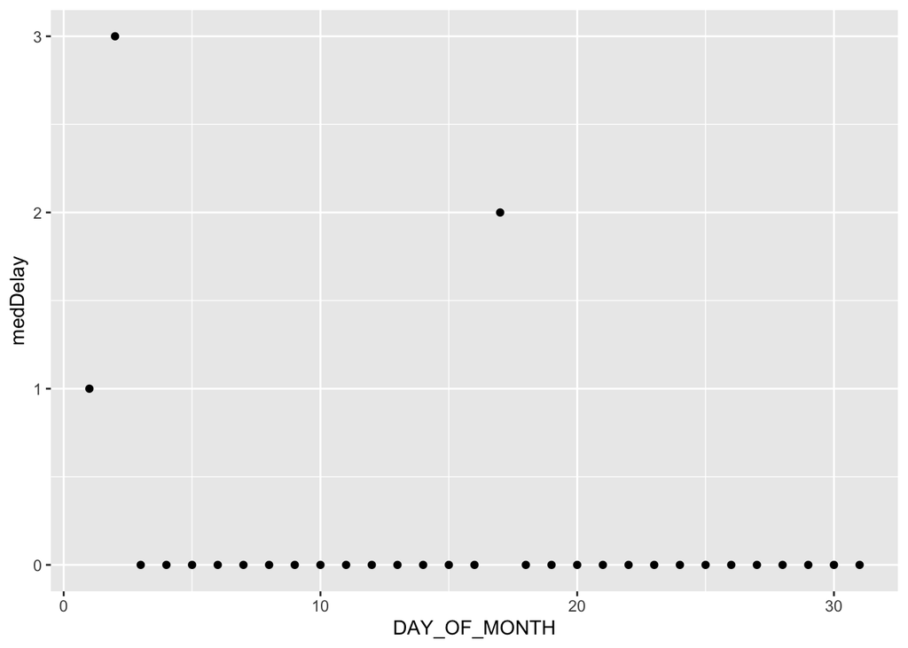

```r
flightDataTB %>%
  filter(ORIGIN == 'IAH' | ORIGIN == 'DFW') %>%
  group_by(DAY_OF_MONTH) %>%
  summarise(medDelay = median(DEP_DELAY_NEW, na.rm = TRUE)) %>%
  ggplot(.) +
    geom_point(mapping = aes(x = DAY_OF_MONTH, y = medDelay))
```

It’s notable that two of the highest median delays occured on the first two days. Perhaps it is related to weather or maybe the holiday?